# The OES Guide to Making and Evaluating Matched Designs (DRAFT!!)

Author

Jake Bowers and Ben Jaques-Leslie

Published

June 16, 2026

**Code to load libraries and general setup**

```r
if(!require(renv)){
    install.packages("renv",method="wget")
}
library(tidyverse)
library(RItools)
library(optmatch)
library(designmatch)
library(highs)
library(coin)
library(conflicted)
library(estimatr)
library(senstrat)
library(sensemakr)
conflicts_prefer(dplyr::select)
conflicts_prefer(dplyr::filter)
conflicts_prefer(optmatch::strata)
options(digits=4,scipen=8)
```

# 1 Overview

We create matched research designs to address alternative explanations. Say we have a policy intervention, $Z$, that we code as $Z_i=0$ for people, $i$, who did not experience the intervention and $Z_i=1$ for those who did experience the intervention, and an outcome that we observe for each person, $Y_i$. We would like to know whether the outcome among people who experienced the intervention ($Y_i|Z_i=1$) is different from the outcome among those who did not experience the intervention ($Y_i|Z_i=0$) **because of the intervention rather than some other factor, $x_i$**. A matched design will only compare $Y_i|Z_i=1$ with $Y_i|Z_i=0$ **within strata of people who are similar on their values of $x_i$ in an effort to set aside $x_i$ as an explanation of the difference in outcomes.**

For example, say the intervention is a job training program and the outcome is income and we see that people who took the job training program have higher incomes than people who did not. One explanation for the difference could be that the job training program helped people earn more. An alternative explanation might be that that older people took the job training program and, because they have more workforce experience tend to earn higher wages than younger people and were also more likely to sign up for the job training program. We can address this alternative explanation by creating strata of people who have the same age and only comparing incomes between those who took the training program and those who did not among people of the same age. For example, we might write the difference in average income between job training alumni and those who did not take job training among people who are 18 years old as $\bar{Y}=(\bar{Y}|Z=1,X=18)-(\bar{Y}|Z=0,X=18)$. Within that strata of 18 year olds, there are no differences in age. So, comparisons in income between those with the job training and without cannot be interepreted as arising from differences in age (unless age differences in month or week matter). If age differences tend to only matter if the differences in age are a matter of years, then we can create a research design that **adjusts for this alternative explanation** by restricting our comparisons to people who are the same age: creating strata of 18 year olds, 19 year olds, etc $\ldots$.

In this memo, we discuss generalizations of this basic approach: from exactly matching on a single variable to exclude alternative explanations based on that variable alone, to matching on a number of variables all at once in the hopes that we might set aside a number of alternative explanations all together.

Although we eventually will want to estimate values for and test hypotheses about causal effects, this creation of a matched design is a research design step because it can be done without knowledge of the values for the outcome variables.[^1] This separation of design from outcome analysis allows us to use the data to make design decisions without worrying about harming the false positive rates of our tests. Those who wish to follow up on the general ideas presented here might like to see Paul R. Rosenbaum (2020a), Paul R. Rosenbaum (2020b).

This memo also is a code tutorial, showing examples throughout. It is currently only using R because that is the language where those who have been developing modern approaches to the creation of matched designs are working.

## 1.1 Roadmap

**Stage 1: The simplest case.** We begin with a matched design that has only two strata and one covariate. This simple case introduces the core ideas of stratification, within-strata estimation, and weighted combination of strata-specific effects — ideas that carry through everything that follows.

**Stage 3: Evaluating and improving the design.** A matched design is not accepted or rejected in a single step — it is iterated. We show two complementary ways to assess a design: inspecting within-set differences on substantively important variables, and comparing the overall design to the covariate balance we would expect from a randomized experiment using the omnibus test in `balanceTest`. We explain in detail what that test is doing so that its output can be interpreted and acted upon.

# 2 Create Data

To make this guide portable, we are making up a fake dataset with covariates that help determine the probability of treatment.

```r
N <- 1000
set.seed(12345)
dat <- data.frame(id = 1:N)
dat <- dat %>% mutate(
  sso = sample(1:10, size = N, replace = TRUE),
  age = rnorm(n = N, mean = 45, sd = 10),
  sex = factor(sample(c("M", "F"), size = N, replace = TRUE)),
  race = factor(sample(c("A", "B", "W"), size = N, replace = TRUE, prob = c(.05, .15, .8))),
  u = rnorm(n = N, mean = sso, sd = exp(sso)),
  demog_latent0 = .5 * sd(u) * age + .2 * sd(u) * as.numeric(sex) + .2 * sd(u) * as.numeric(race) + u,
  demog = (demog_latent0 - min(demog_latent0)) / (max(demog_latent0) - min(demog_latent0)),
  edu = factor(sample(letters[1:8], size = N, prob = runif(n = 8, min = .1, max = pmax(.2, demog)), replace = TRUE)),
  grade = sample(1:6, size = N, replace = TRUE),
  pay = abs(rnorm(n = N, mean = (demog + .01) * 50000 + 50000, sd = 50000)),
  tenure = rnorm(n = N, mean = 10, sd = 3),
  perf = runif(n = N, min = 1, max = 10),
  preY0 = abs(.2 * demog + rnorm(N)),
  preY = (preY0 - min(preY0)) / (max(preY0) - min(preY0)),
  trtcont = rnorm(n = N, mean = demog + preY, sd = sd(demog + preY)),
  ##  trtbin = rbinom(n = N, size = 1, prob = pmin(.95,demog+preY)),
  trtbin = as.numeric(trtcont >= quantile(trtcont, 2 / 3)),
  postY = .2 * sd(preY) * trtbin + preY + rnorm(N)
)

## optmatch will need row names
row.names(dat) <- dat$id
## Just verifying that trtbin is related to demog and preY
## table(dat$trtbin, exclude = c())
## with(dat, boxplot(demog ~ trtbin))
## with(dat, boxplot(preY ~ trtbin))

## Check the relationship between demog and its components. Not really using demog directly below.
## The idea is to ensure some relationships among the covariates using demog.
lm1 <- lm(demog ~ sso + age + sex + race + edu, data = dat)
#  summary(lm1)
lm2 <- lm(preY ~ demog, data = dat)
# summary(lm2)

# cor(dat[, c("age", "demog", "pay", "preY")])
```

Our goal is to assess the effect of some observed intervention (that we call `trtbin` here for the binary version or `trtcont`) on some outcome (that we call `postY`). We worry that a naive description of the relationship between intervention and outcome would not provide useful policy guidance because any such simple two-way relationship might contain other relationships (say, those driven by age or education in this example). From a policy standpoint we can change the intervention but we cannot change the education or age of people, so we want to remove the influence of age and education (among other relatively fixed characteristics of people) from our description. That is, we want to be able to **interpret** the relationship we calculate between intervention and outcome as reflecting, as much as possible, only the intervention and the outcome and not age and education.[^2]

# 3 The simplest matched design: 2 strata, 1 variable

As an example of where we are going, we show an example of what is, in essence, a matched design, but one that has only 2 strata and using only 1 variable. Here we will also show the outcome analysis, just to be clear about how stratification can enable adjustment or substitute for linear additive “controlling for”.

Say that we want to remove the effect of sex from the relationship between the intervention and the outcome. The simplest and most transparent way to do this would be to calculate the relationship between the intervention and the outcome only among men and only among women (imagining that our administrative data do not yet record non-binary gender).

Below we show this most basic approach to using stratification to remove or control for the effects of a single variable with two levels as a way to introduce multivariate optimal matching later. What we see here is that the effect among men is different from the effect among women, and that the effect among each sex cannot be confounded by sex — after all the variables `sex` is held perfectly constant.

```r
with(dat, table(treated=trtbin, sex=sex, exclude = c()))
```

```
       sex
treated   F   M
      0 327 339
      1 169 165
```

```r
lm_sexM <- lm(postY ~ trtbin, data = dat, subset = sex == "M")
lm_sexF <- lm(postY ~ trtbin, data = dat, subset = sex == "F")
coef(lm_sexM)[["trtbin"]]
```

```
[1] 0.3205
```

```r
coef(lm_sexF)[["trtbin"]]
```

```
[1] 0.2076
```

Now, these are two descriptions of the relationship of interest, but we tend to think about stratification as a way to *remove* confounding relationships from *a single overall* relationship. How to calculate this? We show this in steps here — first doing it very simply by hand, and then using “fixed effects”. We will return to these ideas after creating matched designs using `optmatch` and `designmatch` or another approach to stratification since this is the same way that we will estimate effects after creating hundreds of matched pairs or sets later.

We know how to analyze a block-randomized (or strata-randomized) experiment (Gerber and Green 2012): each block is a mini-experiment. We *estimate the ATE within each block* and *combine by weighting each block specific estimate*.

The *block-size weight* produces an unbiased estimator in randomized experiments — in an observational study we don’t know about the bias since we don’t exactly know how to repeat the study. The *precision weight* (aka the “fixed effects” weights) tends to produce smaller standard errors and confidence intervals but is biased in randomized experiments. In standard practice with matched designs we use the *precision weight* approach because (1) we tend to have matched sets that are nearly the same size (i.e. pairs) which means that the block-size weight and the precision-weight approaches tend to be nearly the same and (2) we can calculate the precision-weighted results quickly using the fact that “fixed effects” in linear regression models create precision weights and (3) we know that our estimators are biased because we neither observe all relevant confounders nor do we know the functional form that relates them to the treatment.

```r
## First collapse the data to the level of the strata and calculate weights
dat_sets <- dat %>%
  group_by(sex) %>%
  summarize(
    nb = n(),
    ateb = mean(postY[trtbin == 1]) - mean(postY[trtbin == 0]),
    prob_trt = mean(trtbin), ## proportion treated in the strata
    nbwt = n() / nrow(dat), ## proportion of the total data in the strata
    prec_wt = nbwt * prob_trt * (1 - prob_trt),
  )

dat_sets$prec_wt_norm <- with(dat_sets, prec_wt / sum(prec_wt))

## The two groups of people with the treatment estimated within each set along with some weights
dat_sets %>% select(sex, nb, ateb, prob_trt, nbwt, prec_wt_norm)
```

```
# A tibble: 2 × 6
  sex      nb  ateb prob_trt  nbwt prec_wt_norm
  <fct> <int> <dbl>    <dbl> <dbl>        <dbl>
1 F       496 0.208    0.341 0.496        0.501
2 M       504 0.321    0.327 0.504        0.499
```

```r
## The overall estimation using the two kinds of weights
est_ate_nw <- with(dat_sets, sum(ateb * nbwt))
est_ate_pw <- with(dat_sets, sum(ateb * prec_wt_norm))

c(block_size_wt = est_ate_nw, precision_wt = est_ate_pw)
```

```
block_size_wt  precision_wt
       0.2645        0.2639
```

Strata-level weights can also be represented at the individual level — and this allows us to use linear models (least squares) to produce block-weighted estimates of the overall average causal effect after “holding constant” sex.

```r
## Now creating the weights at the individual level
dat <- dat %>%
  group_by(sex) %>%
  mutate(
    nb = n(),
    mb = sum(trtbin),
    ateb = mean(postY[trtbin == 1]) - mean(postY[trtbin == 0]),
    prob_trt = mean(trtbin),
    nbwt = (trtbin / prob_trt) + (1 - trtbin) / (1 - prob_trt),
    prec_wt = nbwt * prob_trt * (1 - prob_trt)
  ) %>%
  ungroup()

## Two ways to use the block-size weight
est_ate1a <- difference_in_means(postY ~ trtbin, blocks = sex, data = dat)
est_ate1b <- lm_robust(postY ~ trtbin, weights = nbwt, data = dat)
est_ate1c <- lm(postY ~ trtbin, weights = nbwt, data = dat)

## Three other ways to use the precision or harmonic weight
est_ate2a <- lm_robust(postY ~ trtbin + sex, data = dat)
est_ate2b <- lm_robust(postY ~ trtbin, fixed_effects = ~sex, data = dat)
est_ate2c <- lm_robust(postY ~ trtbin, weights = prec_wt, data = dat)
```

Notice that we get the same result for the overall effect whether we first calculate differences of means within strata and then take a weighted average of those strata specific differences of means, or whether we hand off that job to least squares. The only difference here is whether we choose to weight only using the proportion of the data in the block, or whether we also want to take into account the proportion taking the intervention within the strata.

```r
## Block-size weighted results
c(est_ate_nw, coef(est_ate1a)[["trtbin"]], coef(est_ate1b)[["trtbin"]], coef(est_ate1c)[["trtbin"]])
```

```
[1] 0.2645 0.2645 0.2645 0.2645
```

```r
## Precision weighted results
c(est_ate_pw, coef(est_ate2a)[["trtbin"]], coef(est_ate2b)[["trtbin"]], coef(est_ate2c)[["trtbin"]])
```

```
[1] 0.2639 0.2639 0.2639 0.2639
```

## 3.1 Summary of the section

So, we have seen that we can “control for” a single binary variable using stratification. We didn’t need to evaluate the stratification — after all, we just held sex perfectly constant within strata. If someone asked, “Does this design remove sex as an alternative explanation?” we could answer simply, “Yes. We only compare women with women and men with men.” And we were able to produce an estimate of an overall effect by calculating effects within strata and combining them via weighting. And we showed that we can use OLS for this purpose — just as we would if we had a block-randomized experiment.

What should we do if we have more than one variable? Or if those variables have more than a few values? We explain that below as we introduce optimal matching.

# 4 Create a design, evaluate and iterate if needed

When we created our fake data we made two intervention variables, `trtbin` and `trtcont`, because we want to demonstrate how to use two kinds of approaches to stratification here: **bipartite matching** (which creates sets or pairs of people who differ in a binary variable (i.e. comparing those who received the intervention versus did not) and **non-bipartite matching** (which creates pairs of people who differ in levels of a variable that has more than two values such that each pair should have one person with a higher value and another person with a lower value).

Imagine that we want to compare people who are similar in multiple demographic characteristics as well as baseline outcome (`preY`). We would like to **create a research design** where people are placed into strata where they are as similar as possible with other people along all of those characteristics. If we calculate effects within those strata, we know that we will have minimized the effects of those characteristics on the outcome even if we have not exactly eliminated them as we did above when we exactly controlled “male” versus “female”. In the last decades, algorithms to create strata that minimize differences between people on those covariates have been implemented in relatively user-friendly software (see the list in (Paul R. Rosenbaum 2020a)). In this guide we demonstrate the use of `optmatch` and `designmatch` because each uses a slightly different approach to the minimization problem (both are “optimal” because they solve problems by minimizing).

We demonstrate here how to do this by (1) combining the many variables into single scores via *dimension reduction* and then using the optimal matching algorithms to find strata that minimize the within-strata distances between people on that score (say, using a Mahalanobis distance score and/or a propensity score) and (2) by directly constraining the algorithm (say, restricting research designs to only combine people with fewer than 10 years difference in age).

## 4.1 Bipartite Matching with Optmatch

We will start with the task of comparing people based on their experience of a binary intervention (`trtbin`) using the `optmatch` package.

The general idea in optimal matching is to answer the question, “How shall we break the data into strata?” with “We should choose strata within which differences between units are minimized.” Current software like `optmatch` and `designmatch` create these strata via minimization using **distance matrices**. That is, if we can represent differences between all of the treated and control observations as some form of distances, then we can ask those optimal matching algorithms to find strata that are optimal in the sense of there being no other sets of strata where treated and control units are closer together on that distance. For example, below we make a matrix of absolute differences between each treated unit and each control unit in `preY`:

```r
## Scalar/Absolute differences in baseline outcome
abs_dist <- match_on(trtbin ~ preY, data = dat, method = "euclidean")
abs_dist[1:3, 1:4]
```

```
         control
treatment       2       5      7       9
        1 0.11501 0.17978 0.1305 0.03849
        3 0.28886 0.35363 0.3044 0.21234
        4 0.08072 0.01595 0.0652 0.15724
```

```r
## Notice that the distance between the treated unit labeled "1" and the control unit labeled "5" in the matrix above is simply the absolute difference:
abs(dat["1", "preY"] - dat["5", "preY"])
```

```
    preY
1 0.1798
```

```r
## Optmatch offers us some overview of this distance matrix
summary(abs_dist)
```

```
Membership: 334 treatment, 666 control
Total eligible potential matches: 222444
Total ineligible potential matches: 0

Summary of minimum matchable distance per treatment member:
     Min.   1st Qu.    Median      Mean   3rd Qu.      Max.
0.0000015 0.0001401 0.0004618 0.0098899 0.0014897 0.4002895
```

## 4.2 Dimension reduction

We convert many columns into one column we reduce the dimensions of the dataset (to one column). We can use the idea of **multivariate distance** to produce distance matrices to minimize **multivariate distances**.

We defer in-depth explanation of these scores to (Paul R. Rosenbaum 2020b) for now. I already created the distance matrix recording absolute differences on a single variable `abs_dist` which records the absolute difference in the pre-outcome between people in the treated versus control groups. Below we create multivariate distances in two different ways: a Mahalanobis distance (`mh_dist`) and a standardized distance on propensity score (`ps_dist`). The Mahalanobis distance matrix records the differences in Mahalanobis distance (after transforming the covariates to ranks and scaling, see the (Paul R. Rosenbaum 2020b) section 9.3 on this); and `ps_dist` which records differences in predicted treatment or “propensity score” on the linear predictor scale after standardizing.

```r
### Setup for multivariate distances
covs <- c("sso", "age", "sex", "race", "edu", "grade", "tenure", "preY")
cov_fmla <- reformulate(covs, response = "trtbin")
## A multivariate distance score: Mahalanobis distance on rank transformed covariates
mh_dist <- match_on(cov_fmla, data = dat, method = "rank_mahalanobis")
mh_dist[1:3, 1:4]
```

```
         control
treatment     2     5     7     9
        1 5.199 4.167 4.383 3.491
        3 2.404 3.979 3.230 3.691
        4 3.191 3.504 3.608 3.622
```

```r
## person 213 is closer to person 1 in multivariate terms than person 104
mh_dist[1, c("104", "213")]
```

```
  104   213
5.982 2.360
```

```r
## Here we can compare those two people with person 1 along all of the covariates:
dat %>%
  filter(id %in% c(1, 104, 213)) %>%
  select(one_of(c("trtbin", "id", covs)))
```

```
# A tibble: 3 × 10
  trtbin    id   sso   age sex   race  edu   grade tenure  preY
   <dbl> <int> <int> <dbl> <fct> <fct> <fct> <int>  <dbl> <dbl>
1      1     1     3  53.6 M     W     h         6   7.25 0.302
2      0   104     9  38.1 F     A     a         2  15.8  0.130
3      0   213     5  42.0 M     W     h         6   4.59 0.109
```

```r
summary(mh_dist)
```

```
Membership: 334 treatment, 666 control
Total eligible potential matches: 222444
Total ineligible potential matches: 0

Summary of minimum matchable distance per treatment member:
   Min. 1st Qu.  Median    Mean 3rd Qu.    Max.
  0.283   1.131   1.395   1.461   1.778   2.854
```

This next produces a different distance matrix. Whereas the Mahalanobis distance aims to weight each covariate equally, the **propensity distance** weights the influence of each covariate in the score depending on how predictive it is of the treatment. We often use a logistic regression to produce these scores, but logistic regressions often overfit the data, so below we use a version of logistic regression with the coefficients shrunken towards zero. What really matters here is that the covariates that are *relatively more predictive* than others have larger coefficients in absolute value.

```r
## A multivariate distance score: Propensity score using a logistic regression
## model that shrinks coefficients toward zero to avoid the separation problem
## common in logistic models
## Not loading the arm package because it contains lots of stuff that we don't need so just
## using arm::bayesglm

psmod <- arm::bayesglm(cov_fmla, data = dat, family = binomial())
## Inspect the coefs to make sure that none are too huge
zapsmall(coef(psmod))
```

```
(Intercept)         sso         age        sexM       raceB       raceW
     -6.924      -0.029       0.103      -0.032       0.114       0.178
       edub        educ        edud        edue        eduf        edug
     -0.111      -0.045       0.080       0.092      -0.473       0.204
       eduh       grade      tenure        preY
     -0.366      -0.024       0.007       7.299
```

```r
ps_dist <- match_on(psmod, data = dat)
ps_dist[1:3, 1:4]
```

```
         control
treatment      2     5     7     9
        1 0.6344 0.586 1.069 1.127
        3 1.2726 1.224 1.707 1.765
        4 1.0695 1.021 1.504 1.562
```

```r
ps_dist[1, c("104", "169")]
```

```
    104     169
1.94742 0.01202
```

```r
## Here we can compare those two people with person 1 along all of the
## covariates.
## Notice that control person 169 is closer to treated person 1
## across nearly all of the covariates than person 104 in regards to the
## propensity score

dat %>%
  filter(id %in% c(1, 104, 169)) %>%
  select(one_of(c("trtbin", "id", covs)))
```

```
# A tibble: 3 × 10
  trtbin    id   sso   age sex   race  edu   grade tenure  preY
   <dbl> <int> <int> <dbl> <fct> <fct> <fct> <int>  <dbl> <dbl>
1      1     1     3  53.6 M     W     h         6   7.25 0.302
2      0   104     9  38.1 F     A     a         2  15.8  0.130
3      0   169     8  56.5 M     W     e         3  11.7  0.203
```

```r
summary(ps_dist)
```

```
Membership: 334 treatment, 666 control
Total eligible potential matches: 222444
Total ineligible potential matches: 0

Summary of minimum matchable distance per treatment member:
     Min.   1st Qu.    Median      Mean   3rd Qu.      Max.
0.0000133 0.0009274 0.0030724 0.0854760 0.0155691 2.3015095
```

## 4.3 Creating the stratification using the `optmatch` package

Creating the stratification using the `pairmatch` and `fullmatch` commands in the optmatch package just requires that the researcher provide an appropriately formatted distance matrix to those functions.

```r
## A paired design
pm1 <- pairmatch(mh_dist, data = dat)
summary(pm1)
```

```
Structure of matched sets:
1:1 0:1
334 332
Effective Sample Size:  334
(equivalent number of matched pairs).
```

```r
stopifnot(all.equal(names(pm1), row.names(dat)))
dat$pm1 <- factor(pm1)

dat %>%
  filter(pm1 %in% c("1.1", "1.2")) %>%
  select(one_of(c("pm1", "trtbin", "id", covs))) %>%
  arrange(pm1, trtbin)
```

```
# A tibble: 4 × 11
  pm1   trtbin    id   sso   age sex   race  edu   grade tenure  preY
  <fct>  <dbl> <int> <int> <dbl> <fct> <fct> <fct> <int>  <dbl> <dbl>
1 1.1        0   476     5  47.8 M     W     h         4   5.07 0.115
2 1.1        1     1     3  53.6 M     W     h         6   7.25 0.302
3 1.2        0   224    10  38.4 F     W     f         3   9.27 0.358
4 1.2        1     3     8  51.1 F     W     f         3   7.63 0.476
```

We can also ask for a match with a variable number of controls and treated units in each set where the number of controls per treated and treated per control are chosen to minimize overall balance using **fullmatch** (Hansen 2004). Below we show a fully-matched design called `fm1_unrestricted` in which no control units are excluded. And we compare this design to one where we restrict this design to have no more than 1 treated unit per set and no more than 5 controls per set.[^3]

```r
fm_unrestricted <- fullmatch(mh_dist, data = dat)
summary(fm_unrestricted, min.controls = 0, max.controls = Inf)
```

```
Structure of matched sets:
 1:1  1:2  1:3  1:4  1:5  1:6  1:7  1:8  1:9 1:11 1:18
 205   52   35   13   11    7    3    3    2    2    1
Effective Sample Size:  397.7
(equivalent number of matched pairs).
```

```r
stopifnot(all.equal(names(fm_unrestricted), row.names(dat)))
dat$fm_unrestricted <- factor(fm_unrestricted)

dat %>%
  filter(fm_unrestricted %in% c("1.1", "1.167")) %>%
  select(one_of(c("fm_unrestricted", "trtbin", "id", covs))) %>%
  arrange(fm_unrestricted, trtbin)
```

```
# A tibble: 8 × 11
  fm_unrestricted trtbin    id   sso   age sex   race  edu   grade tenure   preY
  <fct>            <dbl> <int> <int> <dbl> <fct> <fct> <fct> <int>  <dbl>  <dbl>
1 1.1                  0   476     5  47.8 M     W     h         4   5.07 0.115
2 1.1                  1     1     3  53.6 M     W     h         6   7.25 0.302
3 1.167                0    91     9  53.1 F     W     g         6   9.95 0.0318
4 1.167                0   389     9  41.9 F     W     g         2   9.55 0.0209
5 1.167                0   559     8  49.2 F     W     g         4   5.75 0.0874
6 1.167                0   569     7  51.5 M     W     g         2   7.28 0.140
7 1.167                0   642    10  52.1 M     W     g         4   4.77 0.107
8 1.167                1   524     9  53.5 M     W     g         4   9.25 0.0851
```

```r
## A full-matched design with no more than one treated unit per set and no more than 5 controls per set
fm1 <- fullmatch(mh_dist, min.controls = 1, max.controls = 5, data = dat)
summary(fm1, min.controls = 0, max.controls = Inf)
```

```
Structure of matched sets:
1:1 1:2 1:3 1:4 1:5
194  48  33  18  41
Effective Sample Size:  404.6
(equivalent number of matched pairs).
```

```r
stopifnot(all.equal(names(fm1), row.names(dat)))
dat$fm1 <- factor(fm1)

dat %>%
  filter(fm1 %in% c("1.1", "1.10")) %>%
  select(one_of(c("fm1", "trtbin", "id", covs))) %>%
  arrange(fm1, trtbin)
```

```
# A tibble: 4 × 11
  fm1   trtbin    id   sso   age sex   race  edu   grade tenure   preY
  <fct>  <dbl> <int> <int> <dbl> <fct> <fct> <fct> <int>  <dbl>  <dbl>
1 1.1        0   476     5  47.8 M     W     h         4   5.07 0.115
2 1.1        1     1     3  53.6 M     W     h         6   7.25 0.302
3 1.10       0    66     1  54.0 F     W     h         1   6.29 0.0649
4 1.10       1    25     4  55.9 F     W     h         1   6.33 0.0625
```

In each case the strata (pairs or matched sets) are factor variables named with levels like “1.1” or “1.99” etc.. where these names are not numbers, but “1.1” means “group 1, first set”. And in our case, here we only have one overall group so all of the sets start with `1`: when we use exact matching the first element of the set name will change. We will show this below.

## 4.4 How to assess a matched design?

Did either of those designs do a good job? Should we feel confident using them to remove the influence of the covariates? We have two ways to answer those questions.[^4]

### 4.4.1 Look for substantively large strata-wise differences

First, we can answer this question about design adequacy by referring to what we know about the units and the theory of change and the alternative explanations that we are trying to engage. For example, imagine that we really must remove the effect of age from our comparisons in order for any reasonable interpretation of our analysis to shed light on the effect of the intervention itself and not on age. We might then calculate the difference in age within each set and ask whether any set has such a large difference in age that we could not credibly claim to have “adjusteded away” the potentially confounsing effects of age with this design overall.

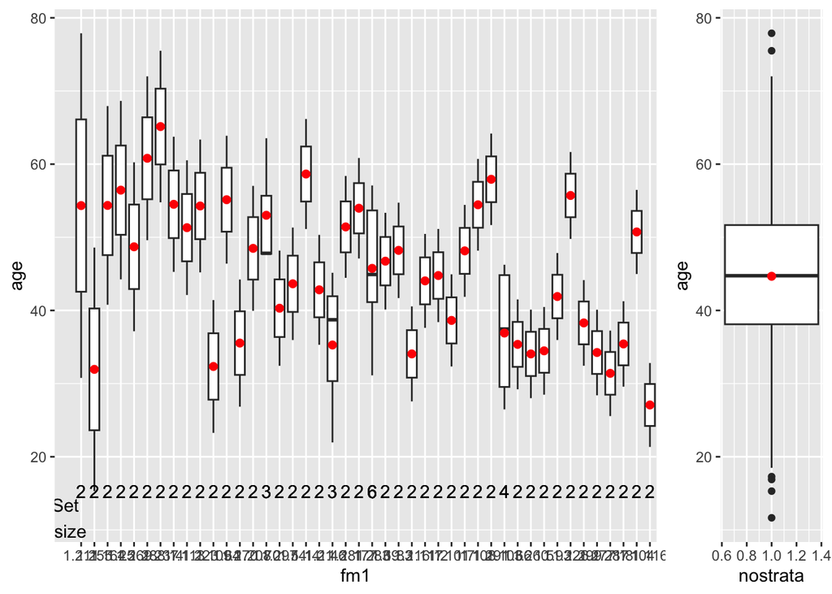

```
# A tibble: 6 × 5
  fm1   mn_age_diffs mn_age min_age max_age
  <fct>        <dbl>  <dbl>   <dbl>   <dbl>
1 1.211         47.1   54.3    30.8    77.9
2 1.255         33.3   31.9    15.3    48.6
3 1.164         27.2   54.4    40.8    67.9
4 1.25          24.4   56.4    44.2    68.6
5 1.269         23.1   48.7    37.2    60.3
6 1.288         22.4   60.8    49.6    72.0
```

```
      0%      10%      20%      30%      40%      50%      60%      70%
 0.08796  1.09232  2.08871  3.20985  3.98536  4.88271  6.21316  8.01687
     80%      90%     100%
 9.92532 12.23069 47.11063
```

### 4.4.2 How to assess stratified research designs as a whole: the omnibus-testing approach

To evaluate the design as a whole, let us start with what we know. Consider a standard against which to compare our design, the block- or strata-randomized experiment. We know that in designs randomized within strata:

- Randomization balances covariate distributions between treated and control groups. **It does not make them identical.**
- We can repeat the known randomization to check the randomization procedure (mostly useful if there is a long chain of communication between the random number generator and the field such that we worry about the implementation of the experiment rather than the random number generator on our computer). This repetition is useful because **we know how strata weighted mean differences in covariates would vary in an experiment.**
- **Randomization does not imply exact equivalence. Large differences in covariates easily arise in small experiments.**

This means that we can compare **stratified observational studies** to equivalent randomized experiments (Hansen and Bowers 2008).

The within-set differences look different from those that would be expected from a randomized experiment.[^5] Below we see that (1) the un-adjusted design (represented with `--` in the `overall` comparison of the data to the standardized mean differences in covariates we would have expected from a randomized experiment) does not look consistent with the experimental standard (the $p$-value is so tiny that we would say that nearly no randomized experiments would have the pattern of imbalance across all of those covariates that we see in our data); (2) And that while the full-matching (`fm1`) and pair-matching (`pm1`) improve the imbalance slightly, neither looks appreciably consistent with a randomized experiment (again, the $p$-values are too small). If, however, we saw a $p$-value of, say, $p=.8$ we would say that the given design has smaller covariate imbalance than 80% of equivalent randomized experiments — which would be a sign that our design compares favorably with randomized experiments.

```r
balfmla_new <- stats::update(cov_fmla,.~.+ strata(fm1)+strata(pm1))
balfmla_new
```

```
trtbin ~ sso + age + sex + race + edu + grade + tenure + preY +
    strata(fm1) + strata(pm1)
```

```r
# trtbin ~ sso + age + sex + race + edu + grade + tenure + preY +
#     strata(fm1) + strata(pm1)

xbfm1 <- balanceTest(balfmla_new, data = dat, p.adjust.method="holm")
xbfm1$overall
```

```
    chisquare df   p.value
fm1     228.8 15 2.880e-40
pm1     166.3 15 1.366e-27
--      282.7 15 2.141e-51
```

Notice that you can also use `independence_test` from the `coin` package for this purpose. This function requires a bit more work on the part of the user, but we show it here just to be clear that this approach can be implemented via at least two pre-packaged pieces of software.

```r
## coin doesn't know what to do with all of these variables of mixed types plus
## it wants a factor variable as the treatment, so the model.matrix command
## expands all of the factors into 0,1 variables. balanceTest does this behind
## the scenes

dat$trtbinF <- factor(dat$trtbin)

##datmm <- data.frame(stats::model.matrix(stats::update(balfmla_new,~.-1-strata(fm1)-strata(pm1)),data=dat))
datmm <- fill.NAs(stats::update(balfmla_new,~.-1-strata(fm1)-strata(pm1)),data=dat,all.covs=TRUE)

datmm$trtbinF <- dat$trtbinF
datmm$trtbin <- dat$trtbin
datmm$fm1 <- dat$fm1

balfmla_new_for_comparison <- reformulate(names(datmm)[!(names(datmm) %in% c("trtbin","trtbinF","fm1"))],response="trtbin")
## trtbin ~ sso + age + sexF + sexM + raceB + raceW + edub + educ + edud + edue + eduf + edug + eduh + grade + tenure + preY

## The version using asymptotic approximations to do the randomization inference
bt_fm1 <- balanceTest(stats::update(balfmla_new_for_comparison,.~.-1+strata(fm1)),data=datmm)
bt_fm1$overall["fm1",]
```

```
    chisquare df  p.value
fm1     228.8 15 2.88e-40
```

```r
xb_fm1 <- xBalance(balfmla_new_for_comparison,strata=list(fm1=~fm1),data=datmm,report="all")
xb_fm1$overall["fm1",]
```

```
    chisquare df  p.value
fm1     228.8 15 2.88e-40
```

```r
## Now independence_test wants the formula to be flipped (rhs versus lhs)
library(formula.tools)
coin_fmla <- ~ trtbinF | fm1

lhs(coin_fmla) <- formula.tools::rhs(balfmla_new_for_comparison)
coin_fmla
```

```
sso + age + sexF + sexM + raceB + raceW + edub + educ + edud +
    edue + eduf + edug + eduh + grade + tenure + preY ~ trtbinF |
    fm1
```

```r
## The version using asymptotic approximations to do the randomization inference
d2_coin_test_asymp <- independence_test(coin_fmla,data=datmm,teststat="quadratic",distribution=asymptotic())
d2_coin_test_asymp
```

```
    Asymptotic General Independence Test

data:  sso, age, sexF, sexM, raceB, raceW, edub, educ, edud, edue, eduf, edug, eduh, grade, tenure, preY by trtbinF (0, 1)
     stratified by fm1
chi-squared = 229, df = 15, p-value <2e-16
```

```r
pvalue(d2_coin_test_asymp)
```

```
[1] <2.22e-16
```

```r
rbind(c(statistic(d2_coin_test_asymp),pvalue(d2_coin_test_asymp)),
bt_fm1$overall["fm1",c(1,3)],
xb_fm1$overall["fm1",c(1,3)])
```

```
     chisquare  p.value
1        228.8 0.00e+00
fm1      228.8 2.88e-40
fm11     228.8 2.88e-40
```

```r
xbfm1_dat <- data.frame(xbfm1$results[,,"fm1"])
xbfm1_dat %>% arrange(desc(abs(z)))
```

```
        Control Treatment  std.diff  adj.diff pooled.sd       z         p
preY    0.18837   0.30478  0.716520  0.116406    0.1625 12.5724 5.388e-35
age    43.85606  48.88442  0.535585  5.028357    9.3885 10.9269 1.457e-26
raceW   0.77375   0.83234  0.152418  0.058583    0.3844  4.0967 6.706e-04
raceB   0.17201   0.13174 -0.115894 -0.040269    0.3475 -3.0587 3.335e-02
edue    0.15220   0.17964  0.074074  0.027445    0.3705  2.4721 1.881e-01
eduh    0.11183   0.08982 -0.071588 -0.022006    0.3074 -2.4219 2.007e-01
raceA   0.05424   0.03593 -0.093668 -0.018313    0.1955 -2.1063 4.221e-01
eduf    0.11138   0.09880 -0.040494 -0.012575    0.3105 -1.7852 8.165e-01
sso     5.67914   5.61078 -0.023938 -0.068363    2.8558 -0.7655 1.000e+00
sexF    0.49232   0.50599  0.027318  0.013673    0.5005  0.6048 1.000e+00
sexM    0.50768   0.49401 -0.027318 -0.013673    0.5005 -0.6048 1.000e+00
edua    0.22635   0.23054  0.010143  0.004192    0.4133  0.5300 1.000e+00
educ    0.14930   0.14371 -0.015836 -0.005589    0.3529 -0.5065 1.000e+00
edub    0.15454   0.15868  0.010996  0.004142    0.3767  0.4996 1.000e+00
tenure  9.98747   9.96524 -0.007545 -0.022230    2.9461 -0.4878 1.000e+00
edud    0.03653   0.03892  0.013117  0.002395    0.1826  0.3536 1.000e+00
grade   3.48368   3.44012 -0.025504 -0.043563    1.7081 -0.3313 1.000e+00
edug    0.05788   0.05988  0.008886  0.001996    0.2246  0.1822 1.000e+00
```

### 4.4.3 What is balanceTest doing?

The balanceTest approach compares the strata-weighted average of within-strata differences to that which would be expected if we were to repeat an experiment with the same stratified design and same covariate values (and `balanceTest` uses a large sample Normal approximation to this distribution.)

```r
setmeanDiffs <- dat %>%
  group_by(fm1) %>%
  summarise(
    diffage = mean(age[trtbin == 1]) - mean(age[trtbin == 0]),
    nb = n(),
    nTb = sum(trtbin),
    nCb = sum(1 - trtbin),
    hwt = (2 * (nCb * nTb) / (nTb + nCb))
  )
setmeanDiffs
```

```
# A tibble: 334 × 6
   fm1   diffage    nb   nTb   nCb   hwt
   <fct>   <dbl> <int> <dbl> <dbl> <dbl>
 1 1.1      5.81     2     1     1  1
 2 1.10     1.96     2     1     1  1
 3 1.100    6.18     3     1     2  1.33
 4 1.101   12.6      2     1     1  1
 5 1.102    8.38     2     1     1  1
 6 1.103   12.5      4     1     3  1.5
 7 1.104   11.5      2     1     1  1
 8 1.105   -4.70     5     1     4  1.6
 9 1.106   10.5      2     1     1  1
10 1.107    2.12     2     1     1  1
# ℹ 324 more rows
```

The test statistic is a weighted average of the set-specific differences (*same approach as we would use to test the null in a block-randomized experiment*). What weight do we use? In this case, `balanceTest` reports as the **descriptive** strata-adjusted mean difference the average of the mean differences within each strata weighted by the number of treated in each strata, one might call this the average effect of treatment on the treated style weighting.

```r
## The descriptive mean difference using block-size weights
with(setmeanDiffs, sum(diffage * nTb / sum(nTb)))
```

```
[1] 5.028
```

```r
## Compare to balanceTest output
xbfm1$results["age","adj.diff" , "fm1"]
```

```
[1] 5.028
```

However, the **test statistic** used to create the $p$-values uses a different weighting scheme which is known to produce the most powerful tests of the null of no differences (Hansen and Bowers 2008). Hansen and Bowers call this a harmonic-mean weight. We could also call it a precision-weight. Or a “fixed-effects” weight. This weight considered both the overall size of the set but also the ratio of treated to control units within each set (both of which would determine the standard error of the estimate of the average treatment effect if it were calculated within a given set).

```r
## The mean diff used as the observed value in the testing is weighted
with(setmeanDiffs, sum(diffage * hwt / sum(hwt)))
```

```
[1] 4.817
```

```r
coef(lm_robust(age~trtbin,fixed_effects=~fm1,data=dat))
```

```
trtbin
 4.817
```

#### 4.4.3.1 Where does the null distribution for the overall test statistic come from?

We will show this distribution in detail here — generating it by hand using code that should be relatively easy to understand (compared to the matrix algebra used for efficiency within the RItools package). But we can also calculate this $p$-value directly using permutations of treatment and control within set using the `coin` package as shown above:

```r
d2_coin_test_asymp <- independence_test(coin_fmla,data=datmm,teststat="quadratic",distribution=asymptotic())
d2_coin_test_asymp
```

```
    Asymptotic General Independence Test

data:  sso, age, sexF, sexM, raceB, raceW, edub, educ, edud, edue, eduf, edug, eduh, grade, tenure, preY by trtbinF (0, 1)
     stratified by fm1
chi-squared = 229, df = 15, p-value <2e-16
```

```r
pvalue(d2_coin_test_asymp)
```

```
[1] <2.22e-16
```

```r
rbind(c(statistic(d2_coin_test_asymp),pvalue(d2_coin_test_asymp)),
bt_fm1$overall["fm1",c(1,3)],
xb_fm1$overall["fm1",c(1,3)])
```

```
     chisquare  p.value
1        228.8 0.00e+00
fm1      228.8 2.88e-40
fm11     228.8 2.88e-40
```

```r
## Notice that the balanceTest from RItools and independence_test from coin have the same test statistic (the precision weighted version)
#cbind(xb_fm1$results[,c("adj.diff","std.diff","z"),],coin_test_stat=matrix(statistic(d2_coin_test_asymp,"standardized"),ncol=1),
#bt_fm1$results[,c("adj.diff","std.diff","z"),])
cbind(bt_fm1$results[,c("adj.diff","std.diff","z"),],coin_test_stat=matrix(statistic(d2_coin_test_asymp,"standardized"),ncol=1))
```

```
        adj.diff  std.diff       z
sso    -0.068363 -0.023678 -0.7655   0.7655
age     5.028357  0.535154 10.9269 -10.9269
sexF    0.013673  0.027317  0.6048  -0.6048
sexM   -0.013673 -0.027317 -0.6048   0.6048
raceB  -0.040269 -0.112259 -3.0587   3.0587
raceW   0.058583  0.147546  4.0967  -4.0967
edub    0.004142  0.011383  0.4996  -0.4996
educ   -0.005589 -0.015788 -0.5065   0.5065
edud    0.002395  0.012557  0.3536  -0.3536
edue    0.027445  0.073741  2.4721  -2.4721
eduf   -0.012575 -0.040968 -1.7852   1.7852
edug    0.001996  0.008470  0.1822  -0.1822
eduh   -0.022006 -0.073056 -2.4219   2.4219
grade  -0.043563 -0.025335 -0.3313   0.3313
tenure -0.022230 -0.007432 -0.4878   0.4878
preY    0.116406  0.710407 12.5724 -12.5724
```

```r
## The version using permutations to do the randomization inference
d2_coin_test_perm<- independence_test(coin_fmla,data=datmm,teststat="quadratic",distribution=approximate(nresample = 10000))
d2_coin_test_perm
```

```
    Approximative General Independence Test

data:  sso, age, sexF, sexM, raceB, raceW, edub, educ, edud, edue, eduf, edug, eduh, grade, tenure, preY by trtbinF (0, 1)
     stratified by fm1
chi-squared = 229, p-value <0.0001
```

```r
## Draw from the two different approximations to the null distribution from the two packages
## Using the same seed for each drawing approach
set.seed(12345)
## These two use the coin package rperm function to draw from the distributions implied by the independence_test (a chisq in one case, and a permutation dist in the other)
null_perm_dist <- rperm(d2_coin_test_perm,10000)
set.seed(12345)
null_asymp_dist <- rperm(d2_coin_test_asymp,10000)
## This next is what is used by balanceTest
set.seed(12345)
bt_dist <- rchisq(n=10000,df=16)
pchisq(bt_fm1$overall["fm1",1],15,lower.tail=FALSE)
```

```
[1] 2.88e-40
```

```r
bt_fm1$overall["fm1",]
```

```
    chisquare df  p.value
fm1     228.8 15 2.88e-40
```

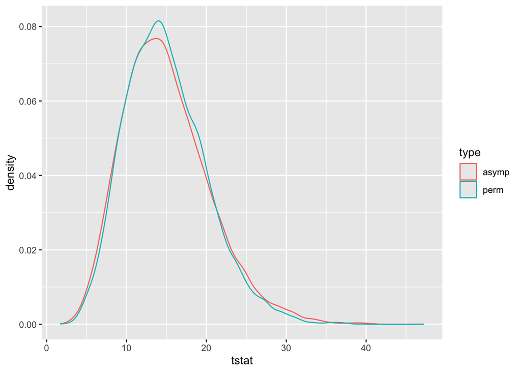

```r
d2_dists <- data.frame(tstat=c(null_perm_dist,null_asymp_dist),type=rep(c("perm","asymp"),each=10000))

dist_compare <- ggplot(d2_dists,aes(x=tstat,group=type,color=type))+
  geom_density()

dist_compare
```

Notice that the $\chi^2$ distributions are very closely approximating the permutation based distribution?

Now we can do the permutations by hand to be more clear about what is going on. We first calculate the $d$-statistics (which are just stratum-weighted differences in means), and then $d^2$ statistic. We generate their distributions using permutations that repeat the design of the putative/metaphorical randomized experiment.

```r
d_stat <- function(covs_dat,trt,strat){
  dat <- cbind(covs_dat,z=trt,s=strat)
  cov_nms <- names(covs_dat)
  datb <- dat %>% group_by(s) %>%
    summarize(across(.cols=one_of(cov_nms),function(x){ mean(x[z==1]) - mean(x[z==0])}),
  nb=n(),
  pib=mean(z),
  nbwt=nb/nrow(dat),
  hbwt0= pib * (1-pib) * nbwt) %>% ungroup()
  datb$hbwt <- datb$hbwt0/sum(datb$hbwt0)
  adjmns <- datb %>% summarize(across(.cols=all_of(cov_nms),function(x){ sum(x*hbwt) }))
  adjmnsmat <- as.matrix(adjmns)
  return(adjmnsmat)
}

test_d_stat <- d_stat(covs_dat=dplyr::select(datmm,-one_of(c("trtbinF","trtbin","fm1"))),trt=datmm$trtbin,strat=datmm$fm1)
## xb_fm1$results[,"adj.diff","fm1"] ## for comparison, the older xBalance function reports the inferential test stats and not the descriptive ones

d2_stat <- function(dstats,ddist=NULL,theinvcov=NULL){
  ## d is the vector of d statistics
  ## ddist is the matrix of the null reference distributions of the d statistics
  if(is.null(theinvcov) & !is.null(ddist)){
    as.numeric( t(dstats) %*% solve(cov(t(ddist))) %*% dstats)
  } else {
    as.numeric( t(dstats) %*% theinvcov %*% dstats)
  }
}

## Now generate the distribution of the d statistics under the null
new_randomization <- function(z,s){
  ## This is for conceptual understanding. So it will be slow.
  newz <- data.frame(z,s) %>% group_by(s) %>% mutate(newz=sample(z)) %>% ungroup() %>% dplyr::select(newz) %>% unlist()
  return(newz)
}

## This should keep the same number of treated and controls in each strata as the original
## we are just shuffling treatment within strata in the same way that we would imagine to
## have done so if we were assigning treatment in a block randomized trial

test_new_rand <- new_randomization(datmm$trtbin,datmm$fm1)
stopifnot(all.equal(table(z=datmm$trtbin,s=datmm$fm1),table(z=test_new_rand,s=datmm$fm1)))
cov_nms <- names(dplyr::select(datmm,-one_of(c("trtbinF","trtbin","fm1"))))

#d_stat(trt=new_randomization(datmm$trtbin,datmm$fm1), covs_dat=datmm[,cov_nms], strat= datmm$fm1)

set.seed(12345)
## This next is fairly slow
d_dist<-replicate(10000, d_stat(trt=new_randomization(datmm$trtbin,datmm$fm1),
  covs_dat=datmm[,cov_nms],
  strat= datmm$fm1))
## only for now:
d_dist <- drop(d_dist) ## for some reason d_dist comes out an array
d_dist[1:3,1:5]
```

```
          [,1]      [,2]      [,3]      [,4]      [,5]
sso  -0.137573 -0.058489 -0.009062 -0.191943  0.134278
age  -0.260292 -0.421580 -0.191245  0.533615 -0.083283
sexF -0.006096 -0.006096 -0.001153  0.003789  0.003789
```

```r
d_dist_cov_mat <- cov(t(d_dist))
inv_dist_cov_mat <- MASS::ginv(d_dist_cov_mat)
## We use the generalized inverse because the cov matrix is nearly singular (not exactly though).
## So, the following produces an error
## invCovDDist <- solve(cov(t(d_dist)))
# Here we can see the preY is close to a linear combination of the other columns
##eigen(d_dist_cov_mat)

## The observed values of the test statistics:
obs_d <- drop(d_stat(trt=datmm$trtbin,covs_dat=datmm[,cov_nms],strat=datmm$fm1))
obs_d2<- d2_stat(obs_d,d_dist,inv_dist_cov_mat)

## The distribution of the d2 test statistic
d2_dist<-apply(d_dist, 2, function(thed){
                 d2_stat(thed,theinvcov=inv_dist_cov_mat)
         })

## The chi-squared reference distribution only uses a one-sided p-value going in the positive direction
d2_p<-mean(d2_dist>=obs_d2)
cbind(obs_d2,d2_p)
bt_fm1$overal

length(d2_dist)

d2_dists <- data.frame(tstat=c(null_perm_dist,null_asymp_dist,d2_dist),type=rep(c("perm","asymp","perm_by_hand"),each=10000))

dist_compare <- ggplot(d2_dists,aes(x=tstat,group=type,color=type))+
  geom_density()

dist_compare
```

[output not shown]

So, we can see that the omnibus test is a test the combines the tests of the nulls for each individual variable. The use of the $\chi^2$ distribution as a large sample approximation to the randomization distribution arises from the fact that we taking a linear combination (a sum) of mean differences, each of which is squared and standardized and has its own Normal distribution (in large samples like the one we are working with here). We have also seen that we can apply the $d^2$ and $d$ tests directly by repeatedly reshuffling the treatment assignment following the matched-design within strata. This foreshadows our recommended approach to estimating causal effects and testing hypotheses about causal effects — we will do so with reference to an as-if-randomized treatment assignment process within each of the strata created by the matching procedure.

## 4.5 Using Designmatch for bipartite matching

Another tool for creating matched designs when you have one intervention group and one control group is provided by the `bmatch` function in the `designmatch` package. It has many options that allow fine-tuning of the stratified design.

To use this function the data have to be sorted in decreasing order of the treatment vector:

```r
library(designmatch)
library(highs)

datmm_dm <- datmm[order(datmm$trtbin,decreasing=TRUE),]

## Convert propensity distance matrix into a form useable by bmatch (because the data was re-ordered):
ps_dist_dm_0 <-as.matrix(ps_dist)[row.names(datmm_dm)[datmm_dm$trtbin==1],row.names(datmm_dm)[datmm_dm$trtbin==0]]
## designmatch is picky about how the distance matrix is scaled
ps_dist_dm<- round(ps_dist_dm_0/mean(ps_dist_dm_0),2)
## See the manual page for distmat() in the designmatch manual for its built in way to produce mahalanobis distance matrices

solverlist <- list(name = "highs", approximate = 1, t_max = 1000, trace = 1)

## bmatch does not do full matching. It defaults to pair matching and allows
## fixed numbers of controls (i.e. every match can be 1 to 2, or 1 to 3, but not a
## mixture of those)

## I'm still a little confused by the subset_weight argument. Sometimes I use
## the total_groups function instead. ## Here I am copying the call to distmatch()
## from designmatch where subset_weight=0 and the emphasis is on minimizing
## distances (just like the pairmatch function in optmatch)

dm1 <- bmatch(t_ind=datmm_dm$trtbin, dist_mat=ps_dist_dm, solver=solverlist, subset_weight=0, total_groups=sum(datmm_dm$trtbin),n_controls=1)

## there is no summary method or other methods to easily inspect the result,
## but we created a function to convert the results of bmatch to a factor like
## that produced by optmatch so that we can use tidyverse to make plots and
## describe quantiles of differences as well as use balanceTest and eventually
## estimate and test.

#' Convert a bmatch object to a data frame for use in merging onto an original data frame
#'
#'
#' @param obj a bmatch object
#' @param origid the vector of identifications from the original data frame
#' @details This function has only been tested with pair matches
bmatch_to_dat <- function(obj,origid) {
  ## This is pair matching. Make sure of it.
  stopifnot(length(obj$t_id) == length(obj$c_id))
  ## We want a factor that we can merge onto our
  ## existing dataset. Here returning a data.frame so that
  ## we can merge --- seems less error prone than using
  ## rownames even if it is slower.
  matchesdat <- data.frame(
    set_id = obj$group_id,
    match_id = c(obj$t_id, obj$c_id)
  )
  matchesdat$id <- origid[matchesdat$match_id]
  return(matchesdat)
}

datmm_dm$id <- row.names(datmm_dm)
dm1_dat <- bmatch_to_dat(dm1,origid=datmm_dm$id)
datmm_dm_res <- left_join(datmm_dm,dm1_dat,by="id")
## This particular design dropped 332 people.
sum(is.na(datmm_dm_res$set_id))
```

```
[1] 332
```

We can evaluate the design produced by `bmatch` just as we did above. Here we just demonstrate balance test since the strata-quantiles approach code is the same as above (modified to use `set_id` rather than `fm1`)

```r
dm1_fm1 <- balanceTest(stats::update(balfmla_new_for_comparison,.~.-1+strata(set_id)),data=datmm_dm_res)
dm1_fm1$overall["set_id",]
```

```
       chisquare df   p.value
set_id     131.1 15 1.319e-20
```

### 4.5.1 Tools to improve design

So far we have not done a very good job in removing the relationships that exist between the covariates and the intervention (as can be seen from the omnibus balance test p-values or even from directly looking at each strata and the imbalance within them). So, we will try to improve the design by using a few different tactics: (1) Exactly matching based on some important categorical variables such as `sex` (using either the `exactMatch()` function from `optmatch` or the `exact` argument to `bmatch`) (2) And requiring that members of strata differ by no more than a certain amount on either the dimension reduced score (like the propensity score) or one or more specific variables (using either the `caliper()` function from `optmatch` or the `near` argument to bmatch).

## 4.6 Calipers

The optmatch package allows calipers (which forbids certain pairs from being matched).[^6] Here, for example, we forbid comparisons which differ by more than 2 propensity score standardized distances.

Maybe we would prefer to limit the worse matches?

```r
quantile(as.vector(abs_dist), seq(0, 1, .1))
```

```
         0%         10%         20%         30%         40%         50%
0.000001523 0.029795311 0.061439358 0.094979615 0.130364789 0.169838677
        60%         70%         80%         90%        100%
0.215706332 0.270331930 0.347337210 0.461105855 1.000000000
```

```r
fm2 <- fullmatch(abs_dist + caliper(abs_dist, .08), data = dat)
summary(fm2, min.controls = 0, max.controls = Inf)
```

```
Structure of matched sets:
 1:0 18:1 10:1  6:1  5:1  4:1  3:1  2:1  1:1  1:2  1:3  1:4  1:5  1:6  1:7  1:8
  15    1    1    2    1    2    5    9  104   49   23   19   11    7    4    3
 1:9 1:10 1:12 1:13 1:15 1:16
   5    2    2    1    1    2
Effective Sample Size:  332.2
(equivalent number of matched pairs).
```

```r
balfmla_new2 <- stats::update(balfmla_new,.~.+ strata(fm2))
xb2 <- balanceTest(balfmla_new2, data = dat, p.adjust.method="holm")

xb2$overall
```

```
    chisquare df   p.value
fm1     228.8 15 2.880e-40
pm1     166.3 15 1.366e-27
fm2     128.8 15 3.652e-20
--      282.7 15 2.141e-51
```

```r
xb2$results[, , ]
```

```
, , strata = fm1

        stat
vars      Control Treatment  std.diff  adj.diff pooled.sd       z         p
  sso     5.67914   5.61078 -0.023938 -0.068363    2.8558 -0.7655 1.000e+00
  age    43.85606  48.88442  0.535585  5.028357    9.3885 10.9269 1.457e-26
  sexF    0.49232   0.50599  0.027318  0.013673    0.5005  0.6048 1.000e+00
  sexM    0.50768   0.49401 -0.027318 -0.013673    0.5005 -0.6048 1.000e+00
  raceA   0.05424   0.03593 -0.093668 -0.018313    0.1955 -2.1063 4.221e-01
  raceB   0.17201   0.13174 -0.115894 -0.040269    0.3475 -3.0587 3.335e-02
  raceW   0.77375   0.83234  0.152418  0.058583    0.3844  4.0967 6.706e-04
  edua    0.22635   0.23054  0.010143  0.004192    0.4133  0.5300 1.000e+00
  edub    0.15454   0.15868  0.010996  0.004142    0.3767  0.4996 1.000e+00
  educ    0.14930   0.14371 -0.015836 -0.005589    0.3529 -0.5065 1.000e+00
  edud    0.03653   0.03892  0.013117  0.002395    0.1826  0.3536 1.000e+00
  edue    0.15220   0.17964  0.074074  0.027445    0.3705  2.4721 1.881e-01
  eduf    0.11138   0.09880 -0.040494 -0.012575    0.3105 -1.7852 8.165e-01
  edug    0.05788   0.05988  0.008886  0.001996    0.2246  0.1822 1.000e+00
  eduh    0.11183   0.08982 -0.071588 -0.022006    0.3074 -2.4219 2.007e-01
  grade   3.48368   3.44012 -0.025504 -0.043563    1.7081 -0.3313 1.000e+00
  tenure  9.98747   9.96524 -0.007545 -0.022230    2.9461 -0.4878 1.000e+00
  preY    0.18837   0.30478  0.716520  0.116406    0.1625 12.5724 5.388e-35

, , strata = pm1

        stat
vars      Control Treatment  std.diff  adj.diff pooled.sd        z         p
  sso     5.61976   5.61078 -0.003145 -0.008982    2.8558 -0.09009 1.000e+00
  age    45.16781  48.88442  0.395867  3.716607    9.3885  9.05647 2.291e-18
  sexF    0.50000   0.50599  0.011964  0.005988    0.5005  0.53452 1.000e+00
  sexM    0.50000   0.49401 -0.011964 -0.005988    0.5005 -0.53452 1.000e+00
  raceA   0.01497   0.03593  0.107195  0.020958    0.1955  2.33333 2.945e-01
  raceB   0.11976   0.13174  0.034467  0.011976    0.3475  1.41421 1.000e+00
  raceW   0.86527   0.83234 -0.085686 -0.032934    0.3844 -3.05085 3.651e-02
  edua    0.23353   0.23054 -0.007245 -0.002994    0.4133 -0.37796 1.000e+00
  edub    0.16766   0.15868 -0.023846 -0.008982    0.3767 -1.34164 1.000e+00
  educ    0.15269   0.14371 -0.025450 -0.008982    0.3529 -1.73205 9.992e-01
  edud    0.03593   0.03892  0.016396  0.002994    0.1826  1.00000 1.000e+00
  edue    0.16467   0.17964  0.040404  0.014970    0.3705  2.23607 3.549e-01
  eduf    0.10479   0.09880 -0.019283 -0.005988    0.3105 -1.41421 1.000e+00
```

[output cut: 36 more lines]

```
  sexM    0.50901   0.49401 -0.029964 -0.014997    0.5005 -0.4471 1.000e+00
  raceA   0.04354   0.03593 -0.038951 -0.007615    0.1955 -0.5725 1.000e+00
  raceB   0.14865   0.13174 -0.048672 -0.016912    0.3475 -0.7202 1.000e+00
  raceW   0.80781   0.83234  0.063814  0.024528    0.3844  0.9436 1.000e+00
  edua    0.20571   0.23054  0.060092  0.024833    0.4133  0.9026 1.000e+00
  edub    0.18318   0.15868 -0.065046 -0.024501    0.3767 -0.9612 1.000e+00
  educ    0.14715   0.14371 -0.009732 -0.003435    0.3529 -0.1450 1.000e+00
  edud    0.03003   0.03892  0.048695  0.008892    0.1826  0.7420 1.000e+00
  edue    0.14865   0.17964  0.083647  0.030992    0.3705  1.2634 1.000e+00
  eduf    0.11712   0.09880 -0.058978 -0.018315    0.3105 -0.8691 1.000e+00
  edug    0.04655   0.05988  0.059361  0.013334    0.2246  0.9035 1.000e+00
  eduh    0.12162   0.08982 -0.103453 -0.031801    0.3074 -1.5091 1.000e+00
  grade   3.55255   3.44012 -0.065825 -0.112433    1.7081 -0.9873 1.000e+00
  tenure 10.14064   9.96524 -0.059537 -0.175401    2.9461 -0.8806 1.000e+00
  preY    0.16199   0.30478  0.878933  0.142791    0.1625 12.9358 5.085e-37
```

```r
## First inspect the distance matrix itself: how are the distances distributed?
quantile(as.vector(ps_dist), seq(0, 1, .1))
```

```
        0%        10%        20%        30%        40%        50%        60%
0.00001332 0.24555026 0.49633078 0.75520799 1.02384822 1.31702616 1.63474143
       70%        80%        90%       100%
2.00060910 2.44809507 3.08895199 7.31163234
```

```r
## Next, apply a caliper (setting entries to Infinite)
ps_distCal <- ps_dist + caliper(ps_dist, 2)
as.matrix(ps_dist)[5:10, 5:10]
```

```
         control
treatment     11      12     14      15      16    17
       8  1.5957 0.05181 1.0145 1.10926 1.12450 2.591
       10 1.1940 0.34990 0.6128 0.70755 0.72279 2.189
       13 1.4259 0.11801 0.8447 0.93944 0.95468 2.421
       22 0.4457 1.09819 0.1355 0.04075 0.02550 1.441
       23 2.4065 0.86267 1.8254 1.92011 1.93536 3.402
       25 0.4268 1.11705 0.1544 0.05960 0.04436 1.422
```

```r
as.matrix(ps_distCal)[5:10, 5:10]
```

```
       control
treated     11      12     14      15      16    17
     8  1.5957 0.05181 1.0145 1.10926 1.12450   Inf
     10 1.1940 0.34990 0.6128 0.70755 0.72279   Inf
     13 1.4259 0.11801 0.8447 0.93944 0.95468   Inf
     22 0.4457 1.09819 0.1355 0.04075 0.02550 1.441
     23    Inf 0.86267 1.8254 1.92011 1.93536   Inf
     25 0.4268 1.11705 0.1544 0.05960 0.04436 1.422
```

```r
summary(ps_distCal)
```

```
Membership: 334 treatment, 666 control
Total eligible potential matches: 155683
Total ineligible potential matches: 66761

3 unmatchable treatment members:
    128, 338, 699

Summary of minimum matchable distance per treatment member:
     Min.   1st Qu.    Median      Mean   3rd Qu.      Max.
0.0000133 0.0009175 0.0030279 0.0666748 0.0153012 1.3990527
```

## 4.7 Calipers

The optmatch package allows calipers (which forbid certain pairs from being matched).[^7] Here, for example, we forbid comparisons which differ by more than 2 standard deviations on the propensity score. (Notice that we also use the `propensity.model` option to `summary` here to get a quick look at the balance test:)

```r
fmCal1 <- fullmatch(ps_dist + caliper(ps_dist, 2), data = dat, tol = .00001)
summary(fmCal1, min.controls = 0, max.controls = Inf, propensity.model = psmod)
```

```
Structure of matched sets:
 1:0 46:1 14:1  8:1  7:1  5:1  4:1  3:1  2:1  1:1  1:2  1:3  1:4  1:5  1:6  1:7
   3    1    1    1    1    2    4   12   14   83   22   15   11    6    5    6
 1:8  1:9 1:10 1:12 1:13 1:15 1:16 1:19 1:20 1:21 1:55 1:57
   3    2    3    2    1    1    1    1    1    1    1    1
Effective Sample Size:  268.6
(equivalent number of matched pairs).

Balance test overall result:
  chisquare df p.value
       3.24 15   0.999
```

```r
pmCal1 <- pairmatch(ps_dist + caliper(ps_dist, 2), data = dat, remove.unmatchables = TRUE)
summary(pmCal1, propensity.model = psmod)
```

```
Structure of matched sets:
1:0 1:1 0:1
  3 331 335
Effective Sample Size:  331
(equivalent number of matched pairs).

Balance test overall result:
  chisquare df  p.value
        160 15 3.08e-26
```

## 4.8 Calipers

```r
## Create an R formulate object from vectors of variable names
balfmla <- reformulate(c("tenure", "age"), response = "trtbin")

## Create a mahalanobis distance matrix (of rank transformed data)
mhdist <- match_on(balfmla, data = dat, method = "rank_mahalanobis")

## Now make a matrix recording absolute differences between neighborhoods in
## terms of baseline homicide rate
tmppreY <- dat$preY
names(tmppreY) <- rownames(dat)
abs_dist <- match_on(tmppreY, z = dat$trtbin, data = dat)
abs_dist[1:3, 1:3]
```

```
         control
treatment       2       5      7
        1 0.11501 0.17978 0.1305
        3 0.28886 0.35363 0.3044
        4 0.08072 0.01595 0.0652
```

```r
quantile(as.vector(abs_dist), seq(0, 1, .1))
```

```
         0%         10%         20%         30%         40%         50%
0.000001523 0.029795311 0.061439358 0.094979615 0.130364789 0.169838677
        60%         70%         80%         90%        100%
0.215706332 0.270331930 0.347337210 0.461105855 1.000000000
```

```r
quantile(as.vector(mhdist), seq(0, 1, .1))
```

```
      0%      10%      20%      30%      40%      50%      60%      70%
0.004957 0.700828 1.029842 1.309537 1.564325 1.814284 2.068391 2.341284
     80%      90%     100%
2.641912 3.024724 4.684612
```

```r
## Now create a new distance matrix using two calipers:
distCal <- ps_dist + caliper(mhdist, 9) + caliper(abs_dist, 2)
as.matrix(distCal)[5:10, 5:10]
```

```
       control
treated     11      12     14      15      16    17
     8  1.5957 0.05181 1.0145 1.10926 1.12450 2.591
     10 1.1940 0.34990 0.6128 0.70755 0.72279 2.189
     13 1.4259 0.11801 0.8447 0.93944 0.95468 2.421
     22 0.4457 1.09819 0.1355 0.04075 0.02550 1.441
     23 2.4065 0.86267 1.8254 1.92011 1.93536 3.402
     25 0.4268 1.11705 0.1544 0.05960 0.04436 1.422
```

```r
## Compare to:
as.matrix(mhdist)[5:10, 5:10]
```

```
         control
treatment     11     12    14     15     16     17
       8  2.3907 3.0497 2.627 1.8052 2.8429 0.9661
       10 1.0344 0.5325 1.373 1.7082 0.3056 2.6969
       13 0.6030 1.3377 2.361 0.2946 1.7053 2.3717
       22 1.9470 2.5519 2.069 1.4753 2.2860 0.7037
       23 0.5795 1.3164 2.337 0.2935 1.6802 2.3622
       25 0.6274 0.2239 2.015 1.3570 0.9896 2.9278
```

## 4.9 Calipers

Now, use this new matrix for the creation of stratified designs — but possibly excluding some units (also showing here the `tol` argument. The version with the tighter tolerance produces a solution with smaller overall distances)

```r
fmCal2a <- fullmatch(distCal, data = dat, tol = .001)
summary(fmCal2a, min.controls = 0, max.controls = Inf)
```

```
Structure of matched sets:
49:1 14:1  7:1  5:1  4:1  3:1  2:1  1:1  1:2  1:3  1:4  1:5  1:6  1:7  1:8  1:9
   1    1    1    3    5    8   16   90   25   13    9    8    3    8    2    2
1:10 1:11 1:12 1:15 1:16 1:19 1:20 1:21 1:55 1:57
   3    1    2    1    1    1    1    1    1    1
Effective Sample Size:  273.2
(equivalent number of matched pairs).
```

```r
fmCal2b <- fullmatch(distCal, data = dat, tol = .00001)
summary(fmCal2b, min.controls = 0, max.controls = Inf, propensity.model = psmod)
```

```
Structure of matched sets:
49:1 14:1  8:1  7:1  5:1  4:1  3:1  2:1  1:1  1:2  1:3  1:4  1:5  1:6  1:7  1:8
   1    1    1    1    2    4   12   14   83   22   15   11    6    5    6    3
 1:9 1:10 1:12 1:13 1:15 1:16 1:19 1:20 1:21 1:55 1:57
   2    3    2    1    1    1    1    1    1    1    1
Effective Sample Size:  268.6
(equivalent number of matched pairs).

Balance test overall result:
  chisquare df p.value
       2.87 15       1
```

```r
dat$fmCal2a <- fmCal2a
dat$fmCal2b <- fmCal2b

fmCal2a_dists <- matched.distances(fmCal2a, distCal)
fmCal2b_dists <- matched.distances(fmCal2b, distCal)

mean(unlist(fmCal2a_dists))
```

```
[1] 0.06845
```

```r
mean(unlist(fmCal2b_dists))
```

```
[1] 0.06792
```

## 4.10 Exact Matching

We often have covariates that are categorical/nominal and for which we really care about strong balance. One approach to solve this problem is match **exactly** on one or more of such covariates. If the process of matching is going slow, this is also an approach to speed things up.

Here we demonstrate full matching but within categories defined by `grade` (recoded to lo versus high) and gender:

```
     gradeLowHi
grade  hi  lo
    1   0 153
    2   0 179
    3   0 173
    4 163   0
    5 159   0
    6 173   0
```

```r
dist2 <- ps_dist + exactMatch(trtbin ~ gradeLowHi+sex, data = dat)
summary(dist2)
```

```
Summary across all blocks:
Membership: 334 treatment, 666 control
Total eligible potential matches: 55549
Total ineligible potential matches: 166895

Summary of minimum matchable distance per treatment member:
     Min.   1st Qu.    Median      Mean   3rd Qu.      Max.
0.0000594 0.0038009 0.0110234 0.1399394 0.0518460 2.6224127

Block structure:
       Matchable Txt Matchable Ctl Unmatchable Txt Unmatchable Ctl
`hi.F`            79           166               0               0
`lo.F`            90           161               0               0
`hi.M`            78           172               0               0
`lo.M`            87           167               0               0

To see summaries for individual blocks, call for example summary(dist2)$`hi.F`.
```

```r
## or mhdist <- match_on(balfmla,within=exactMatch(trtbin~gradeLowHi,data=dat),data=dat,method="rank_mahalanobis")
## or fmEx1 <- fullmatch(update(balfmla,.~.+strata(gradeLowHi)),data=dat,method="rank_mahalanobis")
fmEx1 <- fullmatch(dist2, data = dat, tol = .00001)
summary(fmEx1, min.controls = 0, max.controls = Inf, propensity.model = psmod)
```

```
Structure of matched sets:
26:1 16:1 13:1 10:1  9:1  7:1  5:1  4:1  3:1  2:1  1:1  1:2  1:3  1:4  1:5  1:6
   1    2    1    1    1    1    1    2    7   15   88   24   21    7    4    6
 1:7  1:8  1:9 1:10 1:11 1:13 1:15 1:17 1:19 1:20 1:27 1:32 1:38 1:41
   3    3    3    2    1    3    1    1    1    1    1    1    1    1
Effective Sample Size:  270.3
(equivalent number of matched pairs).

Balance test overall result:
  chisquare df p.value
       9.11 14   0.824
```

```r
print(fmEx1, grouped = T)
```

[output not shown]

[output cut: 357 more lines]

[output not shown]

```r
dat$fmEx1 <- fmEx1
```

```r
ftable(grade = dat$gradeLowHi, Trt = dat$trtbin, fmEx1, col.vars = c("grade", "Trt"))
```

```
        grade hi    lo
        Trt    0  1  0  1
fmEx1
hi.F.1         1  2  0  0
hi.F.10        1  1  0  0
hi.F.11        1  3  0  0
hi.F.12        1  1  0  0
hi.F.13        3  1  0  0
hi.F.14        1  1  0  0
hi.F.15        1  1  0  0
hi.F.16        1  1  0  0
hi.F.17        1  1  0  0
hi.F.18        3  1  0  0
hi.F.2         1  1  0  0
hi.F.20        8  1  0  0
hi.F.22        1  3  0  0
hi.F.26        1  1  0  0
hi.F.28        1  1  0  0
hi.F.29        8  1  0  0
hi.F.3         1 26  0  0
hi.F.30        1  1  0  0
hi.F.31        1  1  0  0
hi.F.32        1  1  0  0
hi.F.34        6  1  0  0
hi.F.37        2  1  0  0
hi.F.4         1  2  0  0
hi.F.40        1  1  0  0
hi.F.41        1  1  0  0
hi.F.43        1  1  0  0
hi.F.47        2  1  0  0
hi.F.49       13  1  0  0
hi.F.5         3  1  0  0
hi.F.50        3  1  0  0
hi.F.51        1  1  0  0
hi.F.52        1  1  0  0
hi.F.54        2  1  0  0
hi.F.57        1  1  0  0
hi.F.6         1  1  0  0
hi.F.62        1  1  0  0
hi.F.65       10  1  0  0
```

[output cut: 153 more lines]

```
lo.M.55        0  0  3  1
lo.M.56        0  0  4  1
lo.M.57        0  0 32  1
lo.M.6         0  0  1  3
lo.M.69        0  0 19  1
lo.M.7         0  0  1  3
lo.M.72        0  0  2  1
lo.M.73        0  0  1  1
lo.M.75        0  0  3  1
lo.M.78        0  0  1  1
lo.M.79        0  0  2  1
lo.M.8         0  0  1  3
lo.M.80        0  0 13  1
lo.M.83        0  0  2  1
lo.M.85        0  0  4  1
```

### 4.10.1 A further note on exact matching: Splitting up the matching process by hand

If exact matching is still not working, one can directly split up the matching process into separte pieces that would be defined by the exact matching calls above.

In `optmatch` once can follow these kinds of ideas: https://cran.r-project.org/web/packages/optmatch/vignettes/matching-within-subgroups.html. For example, one can first produce the distance matrices of interest and then use `findSubproblems()` to create a list of matrices, each of which can be addressed as its own matching problem (in a loop, for example).

# 5 Non-bipartite matching using `nmatch` from `designmatch`

# 6 Estimating effects and testing hypotheses after matching

### 6.0.1 After bipartite matching

### 6.0.2 After non-bipartite matching

# 7 Assessing sensitivity to unobserved confounders

```r
library(senstrat)
library(sensemakr)
```

## 8 References

Gerber, Alan S, and Donald P Green. 2012. *Field experiments: Design, analysis, and interpretation*. WW Norton.

Hansen, B. B., and J. Bowers. 2008. “Covariate Balance in Simple, Stratified and Clustered Comparative Studies.” *Statistical Science* 23: 219.

Hansen, Ben B. 2004. “Full Matching in an Observational Study of Coaching for the SAT.” *Journal of the American Statistical Association* 99 (467): 609–18.

Kinder, D. R., and T. R. Palfrey. 1993. “On Behalf of an Experimental Political Science.” *Experimental Foundations of Political Science*, 1–39.

Rosenbaum, Paul R. 2020a. “Modern Algorithms for Matching in Observational Studies.” *Annual Review of Statistics and Its Application* 7: 143–76.

Rosenbaum, Paul R. 2020b. *Design of Observational Studies*. 2nd ed. Springer Series in Statistics. Springer.

## Footnotes

[^1]: It is useful to know which units have missing data on the outcomes, but it is not necessary to know the values of the outcomes.
[^2]: We borrow the idea of “interpretable comparisons” from Kinder and Palfrey (1993)
[^3]: We can make other decisions to generate a design that we like later: the decision to restrict the size of the sets has mostly to do with the fact the effective sample size of a stratified research design with two treatments is enhanced as we (a) get more strata and (b) the strata are more equal in size of treated versus controls. We can explain a lot more about this.
[^4]: Another question we should ask about a research design is whether it provides enough information to help us discern differences should those differences exist. We set aside this question of statistical power or information for later. From the perspective of stratified designs, statistical power or information or “effective sample size” is a function of not only number of total observations, but of the number of strata, and the variance of both the treatment and the outcomes within strata. In the case of a binary treatment, variance of the treatment, amounts to the proportion treated. In a matched design that creates pairs, these considerations go away — the number of strata is maximized and each pair has exactly one treated and one control unit. When creating full matched designs — with varying numbers of treated and controls per set — these issues become more important.
[^5]: If you look at the documentation for `balanceTest` you’ll that it can also handle clustered data as well as other options.
[^6]: You can implement penalties by hand.
[^7]: You can implement penalties by hand.